# Data transforms

James Sacco

3/28/2018

## Dependencies

this document depends on the following packages

```r
suppressPackageStartupMessages({
  library(devtools)
  library(Biobase)
})
```

```r
library(devtools)
library(Biobase)
```

## General principles

Make sure data is on the right scale for: Visualization Statistical Modeling

## Load some data

Use this expression set to look at how to use plots and tables to check for different characteristics

```r
con =url("http://bowtie-bio.sourceforge.net/recount/ExpressionSets/bodymap_eset.RData")
load(file=con)
close(con)
bm = bodymap.eset
pdata=pData(bm)
edata=as.data.frame(exprs(bm))
fdata = fData(bm)
ls()
```

```
## [1] "bm"           "bodymap.eset" "con"          "edata"
## [5] "fdata"        "pdata"
```

## Skewed distributions

We would like continuous data to be nice and summetric like a normal distribution for two reasons:(1) plots are easier to see this way and (2) most statistical methods are designed to work better for non-skewed data.

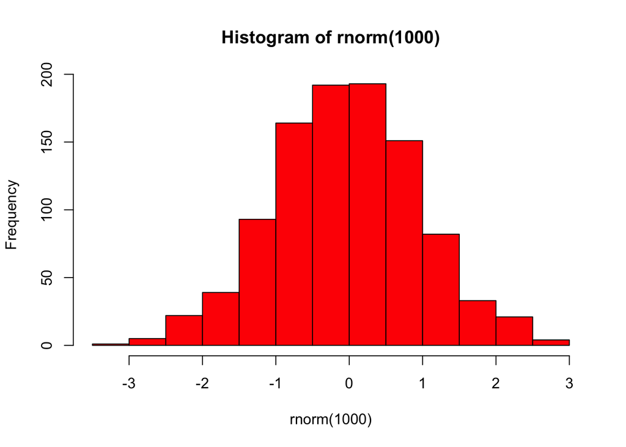

```r
hist(rnorm(1000),col=2)
```

Realistically though most genomic data is skewed

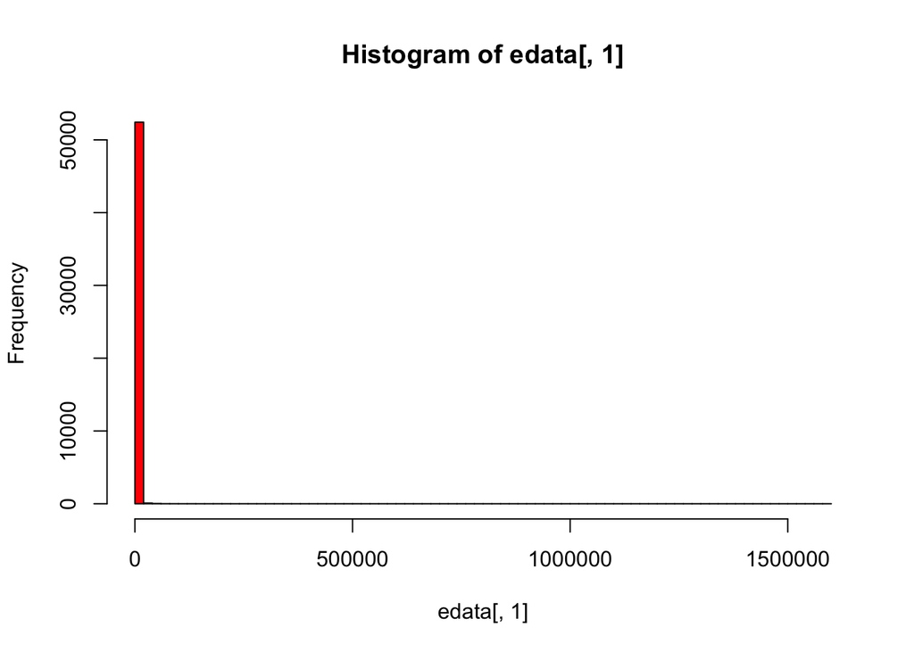

```r
hist(edata[,1],col=2,breaks=100)
```

One way to address this skew is to use a transformation. One common transformation is the log transform.

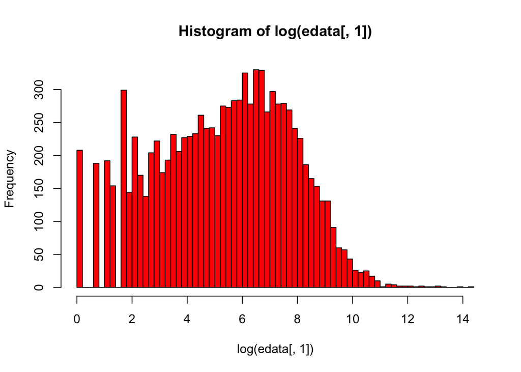

```r
hist(log(edata[,1]),col=2,breaks=100)
```

One thing to be careful with is that values of zero become -inf when you apply the log transform because the log of zero isn’t defined.

```r
min(log(edata))
```

```
## [1] -Inf
```

You can remove this problem by adding a small number to all the counts before taking the log. This doesn’t change the overall distribution much but resolves the zero problem

```r
min(log(edata[,1] + 1))
```

```
## [1] 0
```

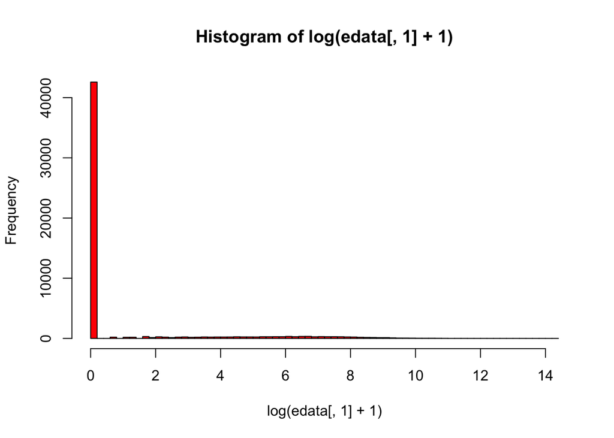

```r
hist(log(edata[,1] + 1),breaks=100,col=2)
```

A common choice is to use the log2 transform. The reason is that data on the log2 scale can be expressed as fold changes. If log2(x) - log2(y) = z then there is a z fold change difference between x and y.

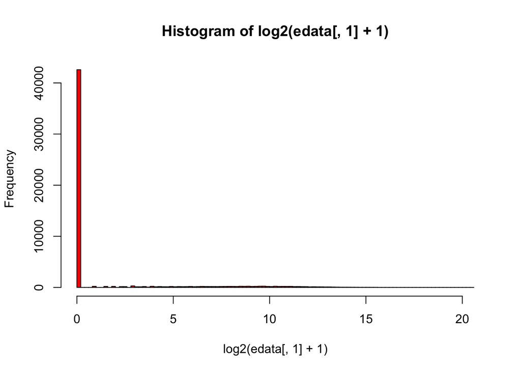

```r
hist(log2(edata[,1] + 1),breaks=100,col=2)
```

Let’s zoom in on the values greater than zero (we’ll come back to the zero values in a minute)

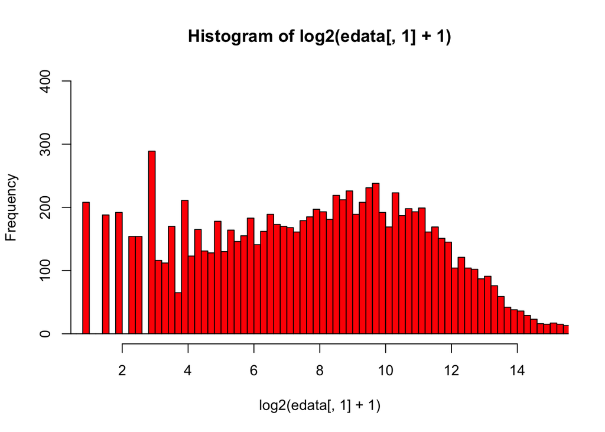

```r
hist(log2(edata[,1] + 1),breaks=100,col=2,xlim=c(1,15),ylim=c(0,400))
```

This is starting to look a little better but we still have the zeros problem.

# Removing features with little data

In many types of sequencing data we observe not much data for many features

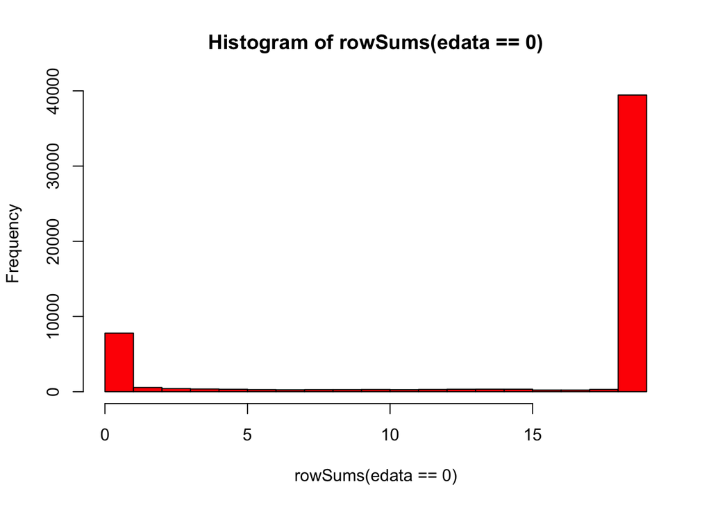

```r
hist(rowSums(edata==0),col=2)
```

A common pre-processing method removes features with low data. One way to identify and remove those features is to use rowMeans and rowMedians

```r
low_genes = rowMeans(edata) < 5
table(low_genes)
```

```
## low_genes
## FALSE  TRUE
## 11413 41167
```

```r
filt_edata = filter(edata,!low_genes)
dim(filt_edata)
```

```
## [1] 52580    19
```

```r
low_genes2 = rowMedians(as.matrix(edata)) < 5
table(low_genes2,low_genes)
```

```
##           low_genes
## low_genes2 FALSE  TRUE
##      FALSE  9844     2
##      TRUE   1569 41165
```

```r
filt_edata2 = filter(edata,!low_genes2)
dim(filt_edata2)
```

```
## [1] 52580    19
```

[figure not shown]

```r
hist(log2(filt_edata[,1] + 1),col=2)
```

# More transforms

There are a large number of other transforms depending on the type of data you are using. Some common ones are:

Variance stabilizing transforms which seek to remove a mean variance relationship among the data Box-Cox transforms which seek to make the data approximately Normally distributed rlog transform - unique to genomics count data, this is a regularized version of the log transform that seeks to minimize differences at low count levels.

```
##  setting  value
##  version  R version 3.3.3 (2017-03-06)
##  system   x86_64, darwin13.4.0
##  ui       X11
##  language (EN)
##  collate  en_US.UTF-8
##  tz       America/Los_Angeles
##  date     2018-03-28
```

```
## Packages -----------------------------------------------------------------
```

```
##  package      * version date       source
##  backports      1.1.2   2017-12-13 CRAN (R 3.3.2)
##  base         * 3.3.3   2017-03-07 local
##  Biobase      * 2.34.0  2016-10-18 Bioconductor
##  BiocGenerics * 0.20.0  2016-10-18 Bioconductor
##  datasets     * 3.3.3   2017-03-07 local
##  devtools     * 1.13.5  2018-02-18 CRAN (R 3.3.3)
##  digest         0.6.15  2018-01-28 CRAN (R 3.3.3)
##  evaluate       0.10.1  2017-06-24 CRAN (R 3.3.2)
##  graphics     * 3.3.3   2017-03-07 local
##  grDevices    * 3.3.3   2017-03-07 local
##  htmltools      0.3.6   2017-04-28 CRAN (R 3.3.2)
##  knitr          1.20    2018-02-20 CRAN (R 3.3.3)
##  magrittr       1.5     2014-11-22 CRAN (R 3.3.0)
##  memoise        1.1.0   2017-04-21 CRAN (R 3.3.2)
##  methods      * 3.3.3   2017-03-07 local
##  parallel     * 3.3.3   2017-03-07 local
##  Rcpp           0.12.16 2018-03-13 CRAN (R 3.3.3)
##  rmarkdown      1.9     2018-03-01 CRAN (R 3.3.3)
##  rprojroot      1.3-2   2018-01-03 CRAN (R 3.3.2)
##  stats        * 3.3.3   2017-03-07 local
##  stringi        1.1.7   2018-03-12 CRAN (R 3.3.3)
##  stringr        1.3.0   2018-02-19 CRAN (R 3.3.3)
##  tools          3.3.3   2017-03-07 local
##  utils        * 3.3.3   2017-03-07 local
##  withr          2.1.2   2018-03-15 CRAN (R 3.3.3)
##  yaml           2.1.18  2018-03-08 CRAN (R 3.3.3)
```